# Séance 5.2: Paramètres de variation

Extensions

Visseho Adjiwanou, PhD.

15 February 2022

## Plan de présentation

- Scores standardisés ou scores-Z
- Loi normale
- Distribution d'échantillonnage
- Théorème central limite
- Intervalles de confiances
- Application

## Scores standardisés ou scores-Z

- Un score standardisé mesure à combien d'écarts-types de la moyenne se situe un score donné
- Sa formule est :

$$Z_i = \frac{X_i - \bar{X}}{s}$$

- $Z_i$ = le score standadisé du $i^e$ cas
- $X_i$ = le score du $i^e$ cas
- $\bar{X}$ = la moyenne
- s = l'écart-type
- Ils sont particulièrement utiles lorsque l'on compare des scores provenant de distribution dont les moyennes et les écarts-types sont différentes.

## Scores standardisés ou scores-Z

- Exemple: Qui de Bill avec un revenu de 80000 au Québec et Alice avec un revenu de 110000 à Alberta a le meilleu revenu dans sa province?
- Rappelons que
- le revenu moyen à Alberta 103446.28 est et l'ecart-type vaut 92722.25
- le revenu moyen au Québec 71150.87 est et l'écart-type vaut 46601.69

## Scores standardisés ou scores-Z

- Calculons les scores standardisés de Bill et de Alice

```r
# Québec
Score_z_bill <- (80000 - 71150.87)/46601.69
Score_z_bill
```

```
## [1] 0.1898886
```

```r
# Alberta
Score_z_alice <- (110000 - 103446.28)/92722.25
Score_z_alice
```

```
## [1] 0.0706812
```

- On voit que Bill a un revenu qui se situe à 0.19 écart type de la moyenne des revenus au Québec alors qu'Alice ne se trouve qu'à 0.07 écart-type. Donc, le revenu de Bill est meilleur que le revenu d'Alice.

## Exercice

Voici les scores de 6 individus:

| Individu | Score (Xi) |
| --- | --- |
| 1 | 64 |
| 2 | 68 |
| 3 | 70 |
| 4 | 71 |
| 5 | 69 |
| 6 | 66 |

1. Calculer les scores sstandardisés (Zi) de chaque individu
2. Calculer la moyenne des scores (Zi). Quelle conclusions tirez-vous?
3. Calculer l'écart-type des scores (Zi). Quelle conclusion tirez-vous?
4. Pouvez-vous démontrer les résultats obtenus au 2 et 3 à partir de la formule du score standardisé?

## Solution

```r
Score <- c(64, 68, 70, 71, 69, 66)
Score
```

```
## [1] 64 68 70 71 69 66
```

```r
Z_score <- (Score - mean(Score))/sd(Score)
Z_score
```

```
## [1] -1.5339300  0.0000000  0.7669650  1.1504475  0.3834825 -0.7669650
```

```r
# Moyenne
mean(Z_score)
```

```
## [1] 0
```

```r
# Écart-type
sd(Z_score)
```

```
## [1] 1
```

## La distribution normale

- La distribution normale est une distribution particulière, symétrique en forme de cloche
- Ce n'est pas toutes les distributions en forme de cloche qui sont normales
- Une distribution normale doit s'écrire sous la forme:

$$Y = \frac{e^{-(x - \mu)^2/2\sigma^2}}{\sigma\sqrt{2\pi}}$$
- $\mu$ est la moyenne et $\sigma$ l'écart-type

- Elle est notée $N(\mu, \sigma)$

## La distribution normale

Voici deux distributions normales

```r
library(tidyverse)
```

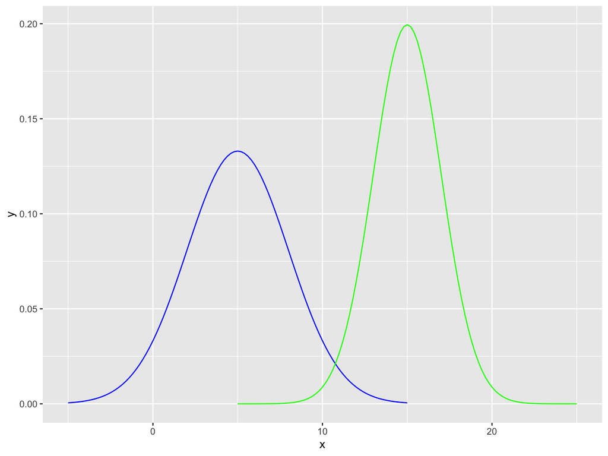

```r
courbe_normale <-
  ggplot(data = data.frame(x = c(-5, 25)), aes(x)) +
  stat_function(fun = dnorm, args = list(mean = 5, sd = 3), color = "blue",
                xlim = c(-5, 15)) +
  stat_function(fun = dnorm, args = list(mean = 15, sd = 2), color = "green",
                xlim = c(5, 25))


courbe_normale
```

## La distribution normale: Propriété

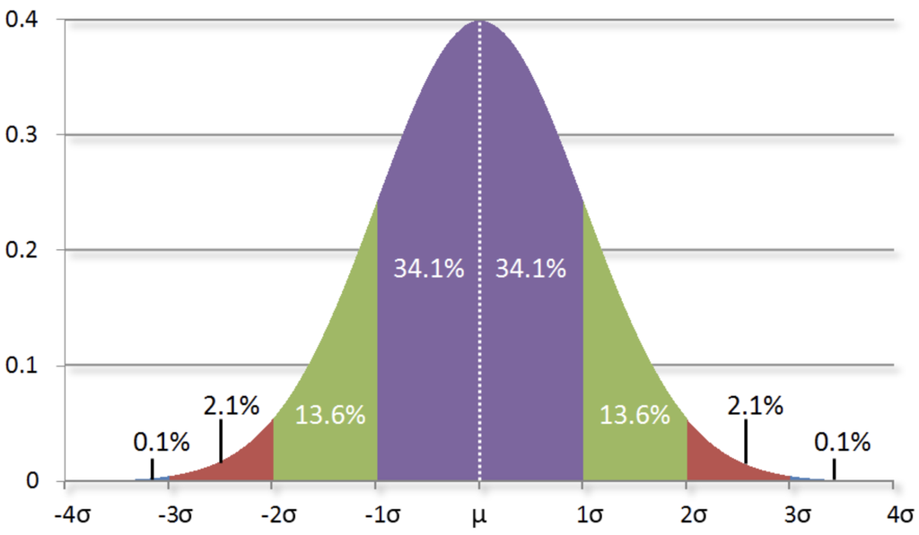

Quelque soit la forme de la loi normale:

1. L'intervalle d'un écart-type de part et d'autre de la moyenne contient 68% de la distribution
2. L'intervalle de deux écart-types de part et d'autre de la moyenne contient 95% de la distribution
3. L'intervalle de trois écart-types de part et d'autre de la moyenne contient 99,7% de la distribution

## Ecart-type correspondant à x pourcentage de la distribution

- Il est préférable de partir de l'intervalle de déterminer plus précisément le nombre d'écart-type qui délimite l'intervalle.
- Par exemple, quel intervalle contient 60% de la distribution?
- Autrement dit, comme la courbe est symétrique, on dira que 30% de la distribution se trouve entre la moyenne et la valeur recherchée. Donc que 20% se trouve au-delà.
- Prob(distribution < v1) = 0.2 nous donne tout simplement la valeur de 20 ième percentile de la distribution
- Prob(distribution < v2) = 0.8 dit que 80% de la distribution est inférieure à cette valeur.
- Donc l'intervalle [V1, V2] contient 60% (80% - 20%) de la distribution

## Ecart-type correspondant à x pourcentage de la distribution

On peut le calculer assez facilement avec la fonction qnorm.

```r
v1 <- qnorm(0.20, mean = 5, sd = 3)
v1
```

```
## [1] 2.475136
```

```r
v2 <- qnorm(0.80, mean = 5, sd = 3)
v2
```

```
## [1] 7.524864
```

- Ainsi, on trouve que l'intervalle en question est [2,47; 7,52] pour la distribution normale N(5, 3).
- Cet intervalle contient 60% de la distribution

## Ecart-type correspondant à x pourcentage de la distribution

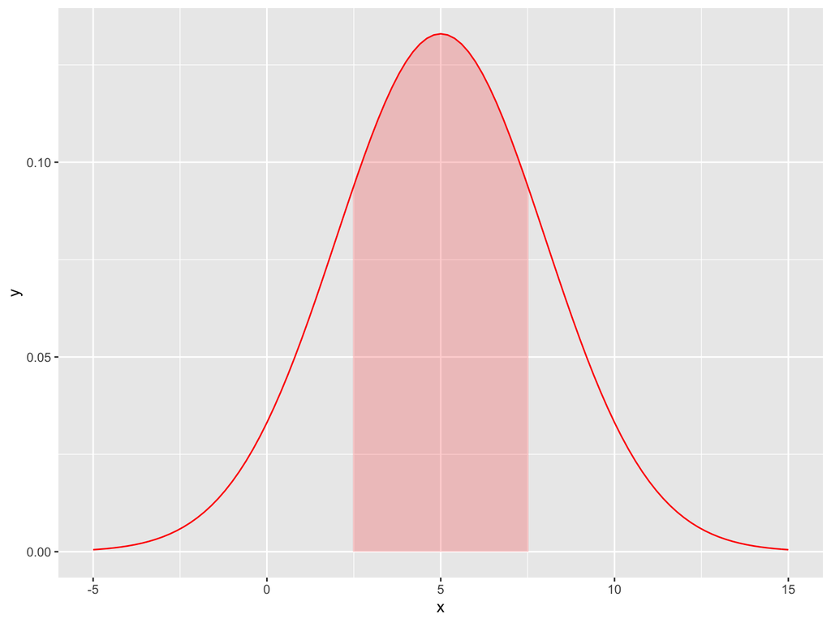

```r
ggplot(data = data.frame(x = c(-5, 15)), aes(x)) +
  stat_function(fun = dnorm, args = list(mean = 5, sd = 3), color = "red") +
  stat_function(fun = dnorm, args = list(mean = 5, sd = 3),
                geom = "area", fill = "red", xlim = c(v1, v2), alpha = 0.2)
```

## Loi normale (centrée réduite)

- Calculer les quantiles pour différentes distributions normales peut être fastidieux (dans le temps).
- Alors, les statisticiens ont calculé cela pour la distribution normale centrée réduite
- Lorsque la moyenne vaut 0 et l'écart-type vaut 1, on parle de distribution normale centrée réduite
- Vous comprenez donc que si vous standardisez les scores de votre distribution normale, vous trouvez une distribution normale centrée réduite

## Loi normale (centrée réduite)

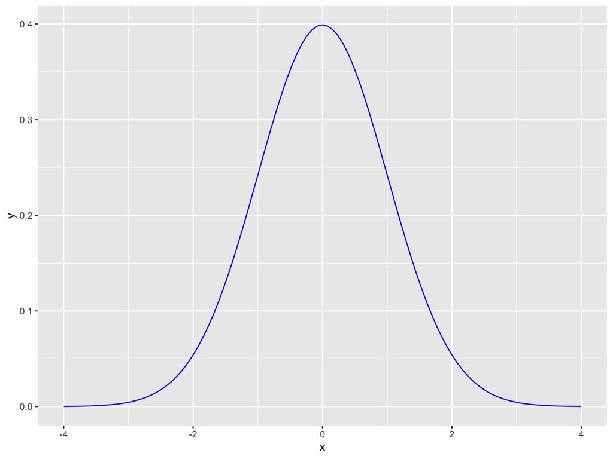

```r
courbe_normale <-
  ggplot(data = data.frame(x = c(-4, 4)), aes(x)) +
  stat_function(fun = dnorm, args = list(mean = 0, sd = 1), color = "blue")

courbe_normale
```

```r
?dnorm
```

## Loi normale (centrée réduite)

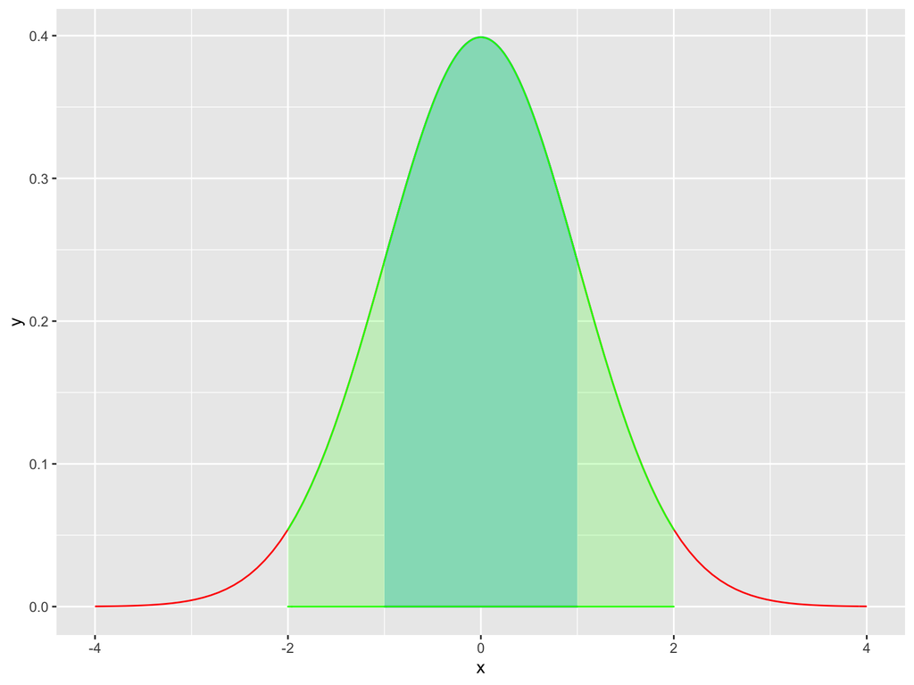

- On voit que 68% de la distribution est comprise entre -1 et 1 écart-type (vert foncé)
- On voit que 95% de la distribution est comprise entre -2 (-1.96) et 2 (1.96) écarts-types (vert clair)

## Lecture du tableau de distribution

Voir livre

# Distribution d'échantillonnage

## Distribution d'échantillonnage

- Il est possible d'utiliser des distributions de données d'échantillon afin de décrire la population de laquelle fut tiré l'échantillon
- Une **distribution d'échantillonnage** (par exemple de la moyenne) est la distribution de l'ensemble des moyennes calculées sur l'ensemble des échantillons possibles de taille N qu'on peut tirer de cet échantillon

## Distribution d'échantillonnage

https://www.alloprof.qc.ca/fr/eleves/bv/mathematiques/les-permutations-les-arrangements-et-les-combinai-m1346

- Exemple simple
- Voici les âges de 4 personnes {10, 11, 13, 14}
- Tirage sans remise de 3 personnes parmi 4: 4!/(4-3)!x3! = 4
- Tirage avec remise : (4+3-1)!/(4-3)!x3! = 6!/1!x3! = 120

## Distribution d'échantillonnage - propriété

- A mesure qu'augmente la taille N de l'échantillon, la distribution d'échantillonnage de la moyenne s'apparente de plus en plus à une distribution normale, dont la moyenne est semblable à celle de la **population** et dont l'écart-type est de $\frac{\sigma}{\sqrt{N}}$
- On nomme cela le **théorème de limite centrale**
- L'écart-type de la distribution d'échantillonnage est appelé **erreur-type**
- Il vaut: $\frac{\sigma}{\sqrt{N}}$

## Exemple

- Supposons que le salaire moyen issu d'un échantillon de 1000 Québécois vaut 65000$ et l'écart-type de 32000.
- On dira que le salaire moyen des Québécois vaut 65000$. Mais, ce faisant on commet une ereur.
- Si nous approximons aussi l'écart-type du salaire de la population par l'écart-type du salaire de l'échantillon, on peut alors dire que l'erreur-type vaut:
- 32000/racine_carré (1000) = 1012

# Intervalle de confiance

## Intervalle de confiance

- La meilleure estimation que nous pouvons avoir de la moyenne de la population est la moyenne de l'échantillon
- Cependant, cette moyenne calculée à partir d'un seul échantillon peut être soit plus élevée, ou plus faible que la vraie moyenne de la population
- Il parait donc extrêmement utile de déterminer l'intervalle, de part et d'autre de la moyenne, à l'intérieur duquel il est probable de trouver la moyenne de la population
- L'erreur-type va nous aider à trouver cela

## Intervalle de confiance

Le théorème de la limite centrale nous permet de déterminer cette intervalle.

- On sait que plus N est grand, plus la distribution d'échantillonnge va suivre la distribution normale N(moyenne de l'échantillon, $\sigma/\sqrt(N)$)
- On sait aussi que dans une distribution normale, 95% de la distribution se trouve à plus ou noins 2 écart-types de la moyenne (plus précisément à 1.96 écart-type)
- Ainsi, l'intervalle de confiance à 95% sera déterminée par:

## Intervalle de confiance

$$[\bar{X} - 1,96\sigma_{\bar{X}} , \bar{X} + 1,96\sigma_{\bar{X}}]$$

- Dans l'exemple précédent, on dira que dans 95% des cas, le salaire moyen de la population Québécoise va se trouver dans l'intervalle [65000 - 1.96*1012, 65000 + 1.96*1012], soit [63016, 66983]
- 1,96 est la valeur du score standardisé correspondant à l'intervalle de 95%

# Théorème central limite - Règle de l'Approximation Normale (généralité)

## Dégré de fiabilité de l'échantillon

- Le but de l'échantillonnage aléatoire est d'éffectuer une inférence relative à la population sous-jacente.
- On souhaite que la moyenne de l'échantillon - $\bar{X}$ soit une estimation proche de la moyenne de la population - $\mu$.
- Deux façons d'étudier le degré d'approximation de $\mu$ par $\bar{X}$.
1. A partir de formules mathématiques
2. A partir de la distribution d'échantillonnage

## Moments de la moyenne de l'échantillon

- On démontre que :
- E($\bar{X}$) = $\mu$ : la moyenne de l'échantillonnage $\bar{X}$ coïncidera en moyenne avec l'objectif, ie. $\bar{X}$ égalisera $\mu$
- Erreur type d'échantillon (standard error) = SE = $\sigma_{\bar{X}}$ = $\frac{\sigma}{\sqrt{n}}$, où $\sigma$ est l'écart type dans la population
- L'erreur type de $\bar{X}$ diminue quand la taille de l'échantillon aléatoire augmente.
- Plus l'échantillon est grand, plus $\bar{X}$ donne une estimation exacte de la moyenne de la population.
- **NB**: Ne pas confondre:
- écart type (en anglais, standard deviation) et
- erreur type ou écart type d'échantillon (en anglais, standard error)

## Forme de la distribution d'échantillonnage

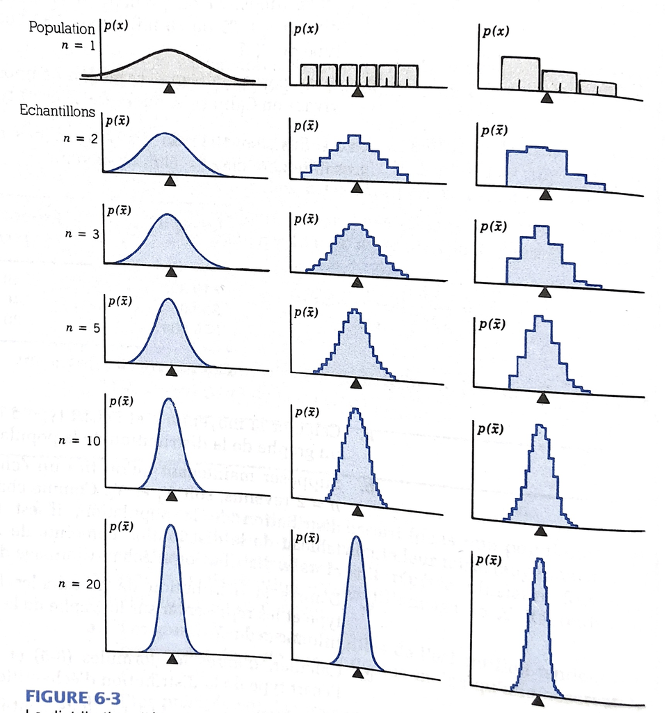

## Théorème central limite (Règle de l'Approximation Normale)

Dans les échantillons aléatoires de taille n, la moyenne de l'échantillon $\bar{X}$ varie autour de la moyenne de la population $\mu$ avec un écart type égal à $\frac{\sigma}{\sqrt{n}}$ (ou $\sigma$ est l'écart type de la population). Donc, quand n s'accroît, la distribution d'échantillonnage de $\bar{X}$ est de plus en plus concentrée autour de son objectif $\mu$. Elle devient de plus en plus proche de la distribution normale (forme de cloche).

## Théorème central limite (Règle de l'Approximation Normale)

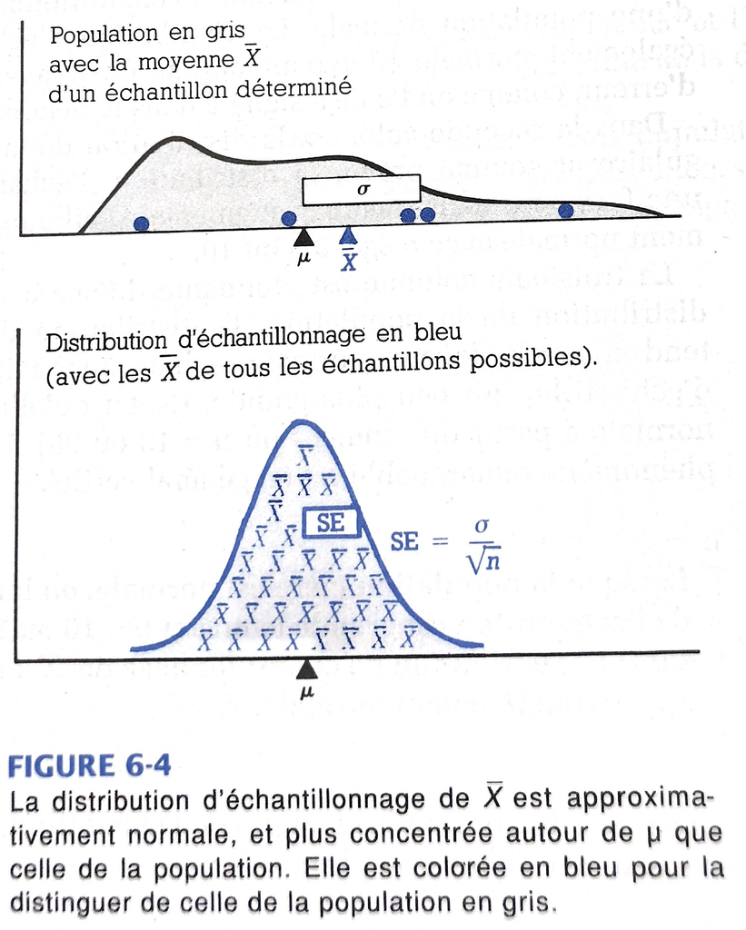

## Théorème de la limite centrale (Règle de l'Approximation Normale)

- Dire que la moyenne de l'échantillon $\bar{X}$ varie autour de la moyenne de la population $\mu$ avec une erreur type $\sigma_{\bar{X}}$ égale à $\frac{\sigma}{\sqrt{n}}$ revient à dire que la distribution $\bar{X}$ suit une loi normale de moyenne $\mu$ et d'écart type $\frac{\sigma}{\sqrt{n}}$
- $\bar{X}$ suit N($\mu$, $\frac{\sigma}{\sqrt{n}}$)
- Ou que ($\frac{(\bar{X}-\mu)}{\frac{\sigma}{\sqrt{n}}}$) suit une loi **normale dite centrée réduite** N(0,1)

## Théorème de la limite centrale (Règle de l'Approximation Normale) - Exemple

Une population d'étudiants d'un grand campus du Middle-West a une taille moyenne de $\mu$ = 175.26 cm (69 inches) et un écart type $\sigma$ = 8.18cm (3.22 inches). Si un échantillon aléatoire de n = 10 individus est prélevé, quelle est la probabilité pour que la moyenne de l'échantillon $\bar{X}$ s'écarte de 5.08 cm (2 inches) de la moyenne de la population?

```r
erreur_type <- 3.22/sqrt(10)
erreur_type
```

```
## [1] 1.018253
```

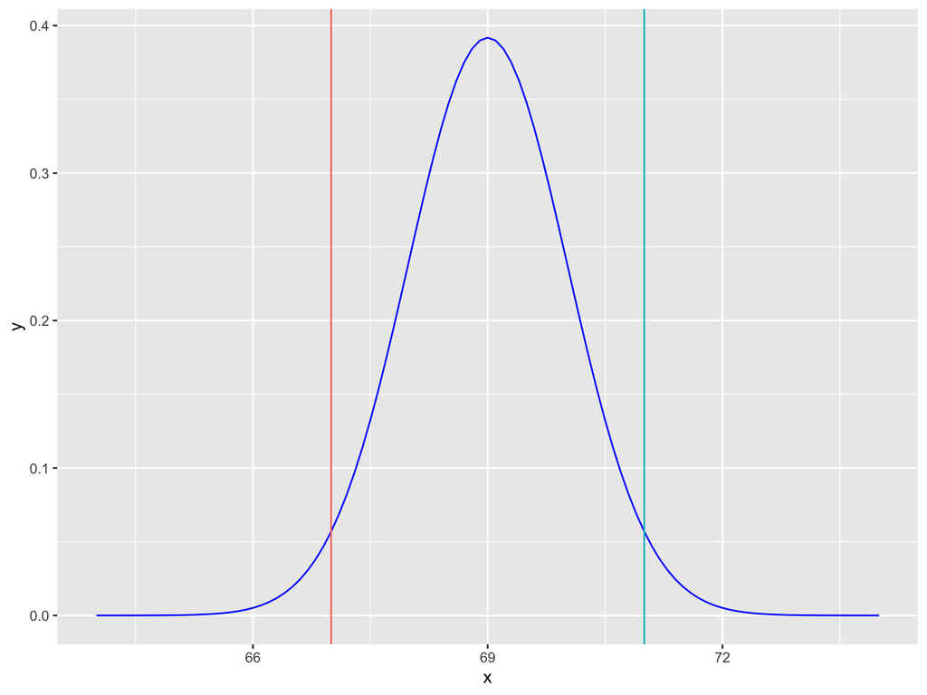

```r
distribution <-
  ggplot(data = data.frame(x = c(64, 74)), aes(x)) +
  stat_function(fun = dnorm, args = list(mean = 69, sd = erreur_type), color = "blue") +
  geom_vline(aes(xintercept = 71, color = "red")) +
  geom_vline(aes(xintercept = 67, color = "green")) +
  theme(legend.position = "none")
distribution
```